# AbSim vignette

Alexander Yermanos

2018-08-17

## 1. Introduction

AbSim is a tool for simulating the evolution of B-cell repertoires. The heavy chain variable region of both human and C57BL/6 mice can be simulated in a time-dependent fashion. Both single lineages using one set of V-, D-, and J-genes or full repertoires can be simulated. The algorithm begins with an initial VDJ recombination event, starting the first phylogenetic tree. Upon completion, the main loop of the algorithm begins, with each iteration representing one simulated time step. Currently, each time step holds three possible events that can either diversify or expand the repertoire: VDJ recombination, somatic hypermutation (SHM), or baseline mutations (sequence death will be added in future versions).

The output of the simulation provides information regarding the sequence composition and the topology of the lineage trees. All sequences are held in the first element of the output list, whereas the corresponding names are held in the second element of the output list. This repertoire can be further expanded by assigning frequencies to each sequence. Additionally, sequences can be sampled at intermediate time points to provide a snapshot of the repertoire in its current state. While the examples focus heavily on phylogenetics, AbSim can be used for a variety of other purposes, from validating error correction methods to testing alignment accuracy. One of the major benefits of AbSim is that the user can control many biologically relevant parameters that are needed to simulate the complex nature of antibody repertoires. This includes size of the repertoire, the number of mutations per branching event, the length of the simulation, the types of somatic hypermutation (SHM), and more. Several examples of both single lineages and full repertoires are displayed below.

## 2. Single lineages

Sometimes it may be desirable to include multiple VDJ events and somatic hypermutation (SHM) events in a single lineage. The singleLineage function allows for branching events to arise from both VDJ recombination and SHM events. This simulation begins with only one set of unmutated germline sequences, which will be used to produce a first VDJ recombination event. The lineage tree begins with one internal node connecting the unmutated germline sequence and the VDJ-recombined sequence. At each time step, there is a possibility for branching events in the form of VDJ recombination (only the unmutated germline can do this) or SHM (all non-germline sequences can undergo this).

While this function draws heavily from the fullRepertoire function (see Section 3), the main difference is that multiple VDJ events can occur within a single tree (determined by the max.VDJ parameter). These VDJ recombinations result in a branching event at the unmutated germline tip. In the full repertoire, VDJ recombination events exclusively start a new tree. An example set of parameters one could call is shown below. The following code randomly selects one set of V-, D-, and J-segments from the C57BL/6 mouse and use only these germline genes to generate the phylogeny. Three independent VDJ recombination events will occur, each of which cause the germline to undergo a branching event. The VDJ recombination events can either follow a naive model, which is the same for both human and mice VDJ recombination events, an “data” based probability distribution based on high throughput sequencing data sets that vary both for mice/human and for VD vs DJ junctions. The user can additionally input a mean and standard deviation for the distribution (will be normally distributed based on these parameter values).

```r
single.lineage.test <- AbSim::singleLineage(max.seq.num=20,max.timer=150,SHM.method="naive",baseline.mut = 0.0008,SHM.branch.prob = "identical", SHM.branch.param = 0.05, SHM.nuc.prob = 15/350,species="mus", max.VDJ = 3, VDJ.branch.prob = 0.3,proportion.sampled = 1,sample.time = 30, chain.type="heavy",vdj.model="naive", vdj.insertion.mean=4,vdj.insertion.stdv=2)
```

### 2.1. Single lineage sequences

```r
head(substring(single.lineage.test[[1]][[1]],first=1,last=20))
```

```
## [1] "caggtccaactgcagcagcc" "caggtccaactgcagcagcc" "caggtccaactgcagcagcc"
## [4] "caggtccaactgcagcagcc" "caggtccaactgcagcagcc" "gaggtccaactgcagcagcc"
```

```r
# Note that these sequences are just showing the first 20 nucleotides (although the full nucleotide sequence is much longer)
```

### 2.2 Single lineage names

The names of the corresponding sequences are held in the second list element. The names provide information regarding which V-, D-, and J-genes were used to start the given lineage, the simulated time step at which the sequence was generated, and how many sequences were already present in the simulation. The names are in the form of a letter, either S or L, corresponding to how the sequence was generated - (“L”=lineage generated by VDJ event or “S”=SHM event). e.g., sequence named “S3_20” indicates that the third sequence of the simulation was generated at the 20th time step through SHM. These sequence names can be subsequently paired with the corresponding sequences as needed (e.g., writing into a fasta file).

```r
head(single.lineage.test[[2]][[1]])
```

```
## [1] "IGHV1-74IGHD5-4IGHJ2" "L1_12"                "S2_12"
## [4] "L3_14"                "S4_14"                "S5_16"
```

```r
# Thus, the sequences and the names can be paired by looking at the corresponding elements in the nested list. E.G single.lineage.test[[1]][[1]][1] corresponds to the sequence of single.lineage.test[[2]][[1]][1]. (In this case it represents the germline)


single.lineage.test[[2]][[1]][3]
```

```
## [1] "S2_12"
```

### 2.3 Single lineage trees

The tree (“phylo” class from R package ape) is held in the third element of the list. In the case of the function singleLineage, there is only one tree, however, when using fullRepertoire function, the other list elements would be stored as the single.lineage.test[[3]][[2]], single.lineage.test[[3]][[3]], etc.

We can plot the trees to see the true phylogeny that was used to generate the lineage/repertoire.

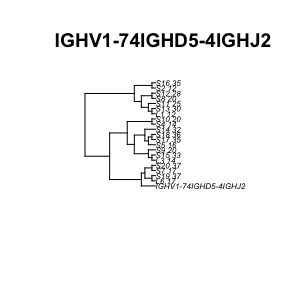

```r
plot(single.lineage.test[[3]][[1]],cex=.5)
title(single.lineage.test[[2]][[1]][1])
```

### 2.4 Single lineage sampling

```r
head(substring(single.lineage.test[[4]],first=1,last=20)) # Shows the sequences of the first sampling time point
```

```
## [1] "caggtccaactgcagcagcc" "caggtccaactgcagcagcc" "caggtcccactgcagcagcc"
## [4] "caggtccaactgcagaatcc" "caggtccaactgcagcagcc" "caggttcaattgcagaatcc"
```

```r
head(single.lineage.test[[5]]) # Names corresponding to above sequences at same time point
```

```
## [1] "S9_20_30"  "L3_14_30"  "S7_17_30"  "S8_20_30"  "L6_17_30"  "S12_28_30"
```

## 3. Full Repertoires

```r
full.repertoire.test <- AbSim::fullRepertoire(max.seq.num=30, max.timer=150, SHM.method="naive", baseline.mut = 0.0008, SHM.branch.prob = "identical", SHM.branch.param = 0.1, SHM.nuc.prob = 15/350, species="mus", VDJ.branch.prob = 0.8, proportion.sampled = 1, sample.time = 15,max.tree.num = 3, chain.type="heavy",vdj.model="naive", vdj.insertion.mean=4,vdj.insertion.stdv=2)
```

### 3.1 Full repertoire sequences

The output of the sequences are stored in the first list element, as similar to the singleLineage (section 2.1). However, now the nested list will have as many elements as there are trees. Thus, the sequences corresponding to the first tree are in full.repertoire.test[[1]][[1]], and the sequences for the second tree are held in full.repertoire.test[[1]][[2]]. As always, the first sequence in the array is the unmutated germline sequence.

```r
head(substring(full.repertoire.test[[1]][[1]],first=1,last=20)) # Sequences corresponding to first tree
```

```
## [1] "caggtccaactgcagcagcc" "caggtccaactgcagcagcc" "caggtccgactgcagcagcc"
## [4] "caggtccaactgcagcagcc" "caggtccaactgcagcagcc" "caggtccaactgcagcagcc"
```

```r
head(substring(full.repertoire.test[[1]][[2]],first=1,last=20)) # Sequences corresponding to second tree
```

```
## [1] "gaggttcagctgcagcagtc" "gaggttcagctgcagcagtc" "gaggttcagctgtagccgtc"
## [4] "gaggttcagctgcagcagtc" "gaggttcagctgcagcagtc" "gaggttcagctgccgcagtc"
```

```r
# Note that these sequences are just showing the first 20 nucleotides (although the full nucleotide sequence is much longer)
```